# Statistical Analysis of Microbiome Data

Author

Katie McCauley from the Bioinformatics and Computational Biosciences Branch (BCBB)

# 1 About the BCBB

- National Institute of Allergy and Infecious Diseases (NIAID)
  - Office of Cyber Infrastructure and Computational Biology (OCICB)
    - Bioinformatics and Computational Biosciences Branch (BCBB)

We are a team of computational biologists, data scientists, bioinformatics software developers, and more! Our interests range from human genomics to structural biology and the microbiome.

We are available for research collaborations, short consultations for bioinformatics questions, assistance with script writing and training on methods or tools.

(Plus, our services are free to the NIAID community!)

You can learn more on our website: [bioinformatics.niaid.nih.gov](https://bioinformatics.niaid.nih.gov/). You will find information about future trainings, can view previous trainings, and start a new collaboration!

# 2 Learning Objectives

Our overarching goal today is to provide you with the tools to start analyzing microbiome data! The specific goals today are:

- Create a Phyloseq Object
- Assess and Explore Raw Microbiome Data
- Standardize/Normalize Sequence Data for Sequencing Depth
- Calculate, compare and visualize:
  - Alpha Diversity (within sample)
  - Beta Diversity (between sample)
  - Individual Taxa
- Identify Networks in Microbiome Data

A few notes before we start:

- I’m sharing the approaches I typically take for analysis and know very well. Throughout the tutorial, I’ll point to alternative methods that are available. There are still active debates about which methods are better. However, I hope that the ideas I share today will at least provide you with avenues of exploration and a platform upon which you can build. And we’re always available for a consult!
- Trouble installing some of the packages? I’ve created an Rstudio instance in the cloud that includes preinstallations of all of the packages we’ll be using today. The code you run and edits you make won’t be saved, but it will let you play around with the data we have today.

[figure not shown]

Binder

Throughout the training, you will see callouts like this with activities and questions.

# 3 Nephele

Before we start, I just wanted to let everyone know about our Nephele platform:

[figure not shown]

The Nephele Splash Page

Most of the analysis we do today will use the Amplicon Metagenomics (DADA2) pipeline results, but the concepts to analyze Shotgun Metagenomics (WGSA2) pipeline results are highly similar.

# 4 Making a Phyloseq Object

[Phyloseq](https://joey711.github.io/phyloseq/) is an R package that allows for relatively simple exploration of microbiome data and keeps the key components you would need all in one easily accessible object[^1]. There are then different and useful accessors and processors that we will get to play around with more today. This diagram gives a detailed view of how each of the components fit together.

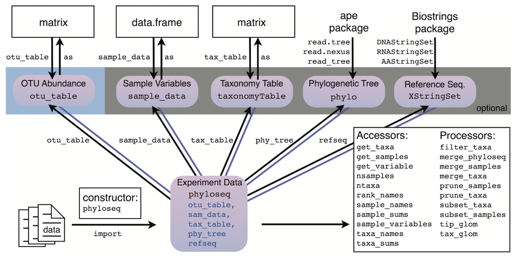

Phyloseq Overview

## 4.1 DADA2

The data that we will be using today is derived from a paper examining differences in the skin microbiome of infants in the United States and Mexico[^2]. I have included the citation and abstract (with relevant highlighting) below.

> Manus MB, Kuthyar S, Perroni-Marañón AG, Núñez-de la Mora A, Amato KR. Infant Skin Bacterial Communities Vary by Skin Site and Infant Age across Populations in Mexico and the United States. mSystems. 2020 Nov 3;5(6):e00834-20. doi: 10.1128/mSystems.00834-20. PMID: 33144313; PMCID: PMC7646528.

**Abstract:** Daily practices put humans in close contact with the surrounding environment, and differences in these practices have an impact on human physiology, development, and health. There is mounting evidence that the microbiome represents an interface that mediates interactions between the human body and the environment. In particular, the skin microbiome serves as the primary interface with the external environment and aids in host immune function by contributing as the first line of defense against pathogens. Despite these important connections, we have only a basic understanding of how the skin microbiome is first established, or which environmental factors contribute to its development. To this end, this study compared the skin bacterial communities of infants (n=47) living in four populations in Mexico and the United States that span the socioeconomic gradient, where we predicted that **variation in physical and social environments would shape the infant skin microbiome**. Results of 16S rRNA bacterial gene sequencing on **119 samples (armpit, hand, and forehead)** showed that infant skin bacterial diversity and composition are shaped by population-level factors, including those related to socioeconomic status and household composition, and vary by skin site and infant age. Differences in infant-environment interactions, including with other people, appear to vary across the populations, likely influencing infant microbial exposures and, in turn, the composition of infant skin bacterial communities. These findings suggest that variation in microbial exposures stemming from the local environment in infancy can impact the establishment of the skin microbiome across body sites, with implications for developmental and health outcomes.

**Activity**

Reviewing the abstract, what are the main conclusions of the authors?

I processed the raw data with Nephele using the parameters the authors provided in their manuscript. However, the tables we analyze today are not identical to the version that the authors generated.

### 4.1.1 Individual Files

During the class, I’ll go through all of the files in the `dada2_outputs` folder. For now, I’ll focus on the important files that we need for analysis.

- OTU_table.txt
- phylo/rooted_tree.nwk

As a side note, I’ve removed the filtered reads (for space reasons) and renamed the folder from `outputs` to `dada2_outputs` for our practice data today. Otherwise, the folder is exactly as you would obtain it from Nephele.

We’ll read in our ASV table, which tells us the counts of reads that were found for each sequence variant within each sample.

```r
library(phyloseq)
library(ggplot2)
setwd("~/OneDrive/training/microbiome-analysis/")
otu <- read.table("data/dada2_outputs/OTU_table.txt", header=T, check.names=F, sep="\t", comment="", quote="", row.names=1)
```

We can explore this file (data frame) using a few basic R commands. I like to do this because it can tell me valuable information about the dataset I have just brought into R, and might help me if I run into issues later.

```r
dim(otu)
```

```
[1] 12206   133
```

```r
otu[1:5,1:5]
```

```
     SRR12823315 SRR12823316 SRR12823317 SRR12823318 SRR12823319
seq1         533        9748       11785       20011         412
seq2       15271         285           0        2257        7014
seq3        2580         146          13         599        1862
seq4          32        2897        4683         113          83
seq5         106         401           0        1126          56
```

**Activity**

How many rows and columns are in the data?

What is the ASV identifier like?

How many seq2 reads does SRR12823315 have?

We first next need to remove the taxonomy information from this table so that it can be added to the phyloseq object separately as the `tax_table` object.

```r
tax <- as.matrix(otu[, c("Kingdom","Phylum","Class","Order","Family","Genus","Species")])
## clean up our OTU table so it no longer includes the taxonomy names
otu[, c("Kingdom","Phylum","Class","Order","Family","Genus","Species")] <- NULL
```

Next, we read in a phylogenetic tree. This file tells us the approximate distance between ASVs, which is calculated through multiple sequence alignment. In most shotgun metagenomic settings, it’s much more difficult to get computationally-meaningful phylogenetic trees for the taxa identified, so you won’t have a phylogenetic tree for any metagenomic data you’re working with.

```r
library(ape)
tree <- read.tree("data/dada2_outputs/phylo/rooted_tree.nwk")
```

Finally, we want to include a table of data about each of the samples.

```r
sampdat <- read.table("data/webinar_demo_metadata.txt", header=T, check.names=F, sep="\t", comment="", quote="")
head(sampdat)
```

```
                              SampleID       ForwardFastqFile
1 Amato.268.HSAP.MEX.19.MM.22.AP.DRY.F SRR12823439_1.fastq.gz
2 Amato.263.HSAP.MEX.19.MM.14.AP.DRY.F SRR12823343_1.fastq.gz
3 Amato.267.HSAP.MEX.19.MM.21.AP.DRY.F SRR12823438_1.fastq.gz
4 Amato.219.HSAP.MEX.19.MM.20.AP.DRY.F SRR12823401_1.fastq.gz
5 Amato.266.HSAP.MEX.19.MM.19.AP.DRY.F SRR12823440_1.fastq.gz
6  Amato.193.HSAP.MEX.19.MM.5.AP.DRY.F SRR12823413_1.fastq.gz
        ReverseFastqFile TreatmentGroup bodysite country population age_months
1 SRR12823439_2.fastq.gz             AP       AP     MEX     Xalapa         33
2 SRR12823343_2.fastq.gz             AP       AP     MEX   Ocotopec         32
3 SRR12823438_2.fastq.gz             AP       AP     MEX     Xalapa         29
4 SRR12823401_2.fastq.gz             AP       AP     MEX     Xalapa         24
5 SRR12823440_2.fastq.gz             AP       AP     MEX     Xalapa         22
6 SRR12823413_2.fastq.gz             AP       AP     MEX   Coatepec         18
  sex number_alloparents number_siblings C_section HH Mom_age_years    Mom_edu
1   M                  3               1       Yes  4            31 Bachelor's
2   F                  3               4        No  6            39    Primary
3   M                  1               0       Yes  3            39 Bachelor's
4   M                  2               0        No  3            36 Bachelor's
5   M                  2               0       Yes  3            30 Bachelor's
6   F                  3               0       Yes  7            20        N/A
  subject_id Description
1  22-MEX-AP SRR12823439
2  14-MEX-AP SRR12823343
3  21-MEX-AP SRR12823438
4  20-MEX-AP SRR12823401
5  19-MEX-AP SRR12823440
6   5-MEX-AP SRR12823413
```

```r
# We need our rownames to reflect our sample names, which are accessible in the `Description` column
rownames(sampdat) <- sampdat$Description
```

Now we can build our phyloseq object that we’ll need for analysis. Note how each of the four components we just read into R has been included in the function.

```r
dada2_phyloseq_object <- phyloseq(otu_table(otu, taxa_are_rows=TRUE), sample_data(sampdat), phy_tree(tree), tax_table(tax))
```

This object can then be summarized by printing it:

```r
dada2_phyloseq_object
```

```
phyloseq-class experiment-level object
otu_table()   OTU Table:         [ 12206 taxa and 126 samples ]
sample_data() Sample Data:       [ 126 samples by 17 sample variables ]
tax_table()   Taxonomy Table:    [ 12206 taxa by 7 taxonomic ranks ]
phy_tree()    Phylogenetic Tree: [ 12206 tips and 12205 internal nodes ]
```

### 4.1.2 Importing using a BIOM file

BIOM files are a special file type that includes not only your count data, but your metadata too. Nephele creates one automatically for several pipelines, including DADA2, QIIME2, WGSA2, and, more recently, BioBakery. Phyloseq has a special function that allows you to quickly import this file.

```r
otu_table_from_biom <- import_biom("data/dada2_outputs/taxa.biom", treefilename = "data/dada2_outputs/phylo/rooted_tree.nwk")
```

This file can also be summarized like above.

```r
otu_table_from_biom
```

```
phyloseq-class experiment-level object
otu_table()   OTU Table:         [ 12206 taxa and 126 samples ]
sample_data() Sample Data:       [ 126 samples by 5 sample variables ]
tax_table()   Taxonomy Table:    [ 12206 taxa by 7 taxonomic ranks ]
phy_tree()    Phylogenetic Tree: [ 12206 tips and 12205 internal nodes ]
```

You’ll notice that the BIOM file contains fewer sample variables. This is because it uses the mapping file submitted to Nephele, and I only submitted one variable (USA vs Mexico) when preparing the mapping file. If your mapping file includes more information, you can use this relatively seamless phyloseq function to bring in your data.

## 4.2 WGSA2

### 4.2.1 Importing from Individual Files

Data from WGSA2 is organized differently. Also, as I had removed larger files from the DADA2 outputs, I’ve also removed the QC’d reads file and the folder for assembly of individual samples. I have a copy of the full expected output and will go through it during training.

At any rate, the files you’ll need to make the files below can be found under `wgsa2_outputs`. You can easily import either:

- Taxonomy-based data: TAXprofiles/readsTAX_RefDB/merged_tables

```r
wgsa2_otu_table <- read.table("data/wgsa2_outputs/TAXprofiles/readsTAX_plusPFV/merged_tables/merged_Counts.txt", header=T, sep="\t", row.names=1)
wgsa2_tax_table <- as.matrix(read.table("data/wgsa2_outputs/TAXprofiles/readsTAX_plusPFV/merged_tables/merged_TAX.txt", header=T, sep="\t", row.names=1))
wgsa2_sample_data <- read.table("data/wgsa2_outputs/mapping_file.txt", header=T, sep="\t", comment="", row.names=1)

wgsa2_phyloseq <- phyloseq(otu_table(wgsa2_otu_table, taxa_are_rows = T), tax_table(wgsa2_tax_table), sample_data(wgsa2_sample_data))
wgsa2_phyloseq
```

```
phyloseq-class experiment-level object
otu_table()   OTU Table:         [ 961 taxa and 3 samples ]
sample_data() Sample Data:       [ 3 samples by 3 sample variables ]
tax_table()   Taxonomy Table:    [ 961 taxa by 7 taxonomic ranks ]
```

- Pathway-based data (what potential pathways do they have?): PWYprofiles/keggPWYs.MP/merged_tables

```r
wgsa2_otu_table_pwy <- read.table("data/wgsa2_outputs/PWYprofiles/keggPWYs.MP/merged_tables/merged_Counts.txt", header=T, sep="\t", row.names=1)
wgsa2_tax_table_pwy <- as.matrix(read.table("data/wgsa2_outputs/PWYprofiles/keggPWYs.MP/merged_tables/merged_allTiers.txt", header=T, sep="\t", row.names=1))

wgsa2_pwy_phyloseq <- phyloseq(otu_table(wgsa2_otu_table_pwy, taxa_are_rows = T), tax_table(wgsa2_tax_table_pwy), sample_data(wgsa2_sample_data))
wgsa2_pwy_phyloseq
```

```
phyloseq-class experiment-level object
otu_table()   OTU Table:         [ 148 taxa and 3 samples ]
sample_data() Sample Data:       [ 3 samples by 3 sample variables ]
tax_table()   Taxonomy Table:    [ 148 taxa by 1 taxonomic ranks ]
```

- Gene-based data (what genes exist?): PWYprofiles/keggPWYs.MP/merged_tables

```r
gene_table <- read.table("data/wgsa2_outputs/PWYprofiles/keggPWYs.MP/merged_tables/merged_geneTPMtable.txt", header=T, check.names=F, sep="\t", comment="", row.names=1)
head(gene_table)
```

```
                                                                                                                            geneNAME
K00001                                                                             E1.1.1.1, adh; alcohol dehydrogenase [EC:1.1.1.1]
K00002                                                                       AKR1A1, adh; alcohol dehydrogenase (NADP+) [EC:1.1.1.2]
K00003                                                                                    hom; homoserine dehydrogenase [EC:1.1.1.3]
K00004 BDH, butB; (R,R)-butanediol dehydrogenase / meso-butanediol dehydrogenase / diacetyl reductase [EC:1.1.1.4 1.1.1.- 1.1.1.303]
K00005                                                                                     gldA; glycerol dehydrogenase [EC:1.1.1.6]
K00007                                                                              dalD; D-arabinitol 4-dehydrogenase [EC:1.1.1.11]
              S1      S28       S6
K00001 732.68900 1409.490 552.7090
K00002  11.67990    0.000  14.7258
K00003 322.09500  561.805 413.3040
K00004 136.11600  274.688 146.2760
K00005 287.05600  254.387 307.7690
K00007   5.39072    0.000   0.0000
```

```r
wgsa2_gene_table <- gene_table[, !names(gene_table) %in% "geneNAME"]
wgsa2_gene_tax <- as.matrix(gene_table[, "geneNAME"])
rownames(wgsa2_gene_tax) <- rownames(gene_table)
colnames(wgsa2_gene_tax) <- "geneNAME"

wgsa2_gene_phyloseq <- phyloseq(otu_table(wgsa2_gene_table, taxa_are_rows = T), tax_table(wgsa2_gene_tax), sample_data(wgsa2_sample_data))
wgsa2_gene_phyloseq
```

```
phyloseq-class experiment-level object
otu_table()   OTU Table:         [ 3455 taxa and 3 samples ]
sample_data() Sample Data:       [ 3 samples by 3 sample variables ]
tax_table()   Taxonomy Table:    [ 3455 taxa by 1 taxonomic ranks ]
```

For now, we will leave all of this data behind because three samples isn’t enough to make major statistical comparisons on, but most of the analysis methods we use below are applicable to data derived from the WGSA2 pipeline.

# 5 Data Assessment

Before we can start answering interesting questions about our data, there are a few things we need to look into.

## 5.1 General Data Exploration

Before doing anything exciting with the data, I simply want to get familiar with what we’re about to analyze, and there are a couple of plots that I generate using phyloseq to help me do that. These types of plots can be incredibly informative as you’re just getting started with a dataset and want to know if everything has been successful so far.

First, is a simple bar plot of the taxa in the dataset:

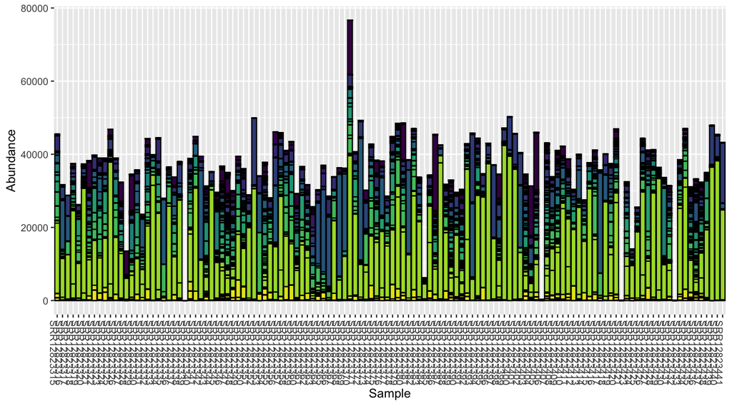

```r
dada2_class <- tax_glom(dada2_phyloseq_object, "Family", NArm = F)
plot_bar(dada2_class, fill="Family") + guides(fill="none") + scale_fill_viridis_d()
```

**Question**

Tell me three things about the data based on this plot.

Another type of figure I like to do very early (and we’ll talk about it more later) is a Principal Coordinates Analysis (PCoA) plot. This plot is useful because it puts samples in relationship to each other. In these plots, samples are points and closer points represent more similar samples while further points represent further samples.

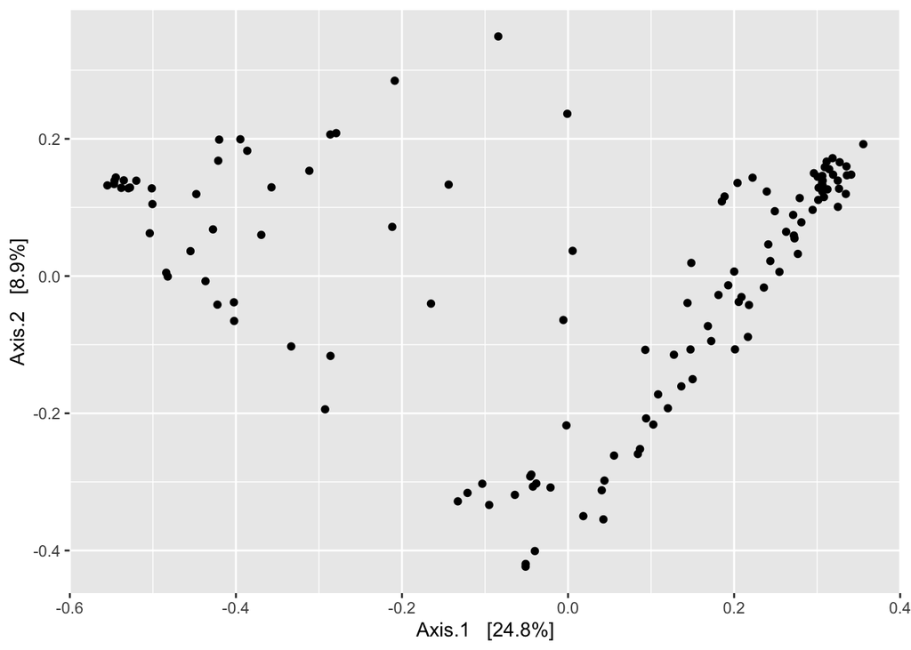

```r
ord <- ordinate(dada2_phyloseq_object, method="PCoA", distance="bray")
plot_ordination(dada2_phyloseq_object, ord)
```

Even without adding any color for different variables, we can already see that samples seem to cluster together in this data. Fortunately, this is expected because we know that the study is looking at three different body sites, and as I just hinted at, we can add color to visualize this:

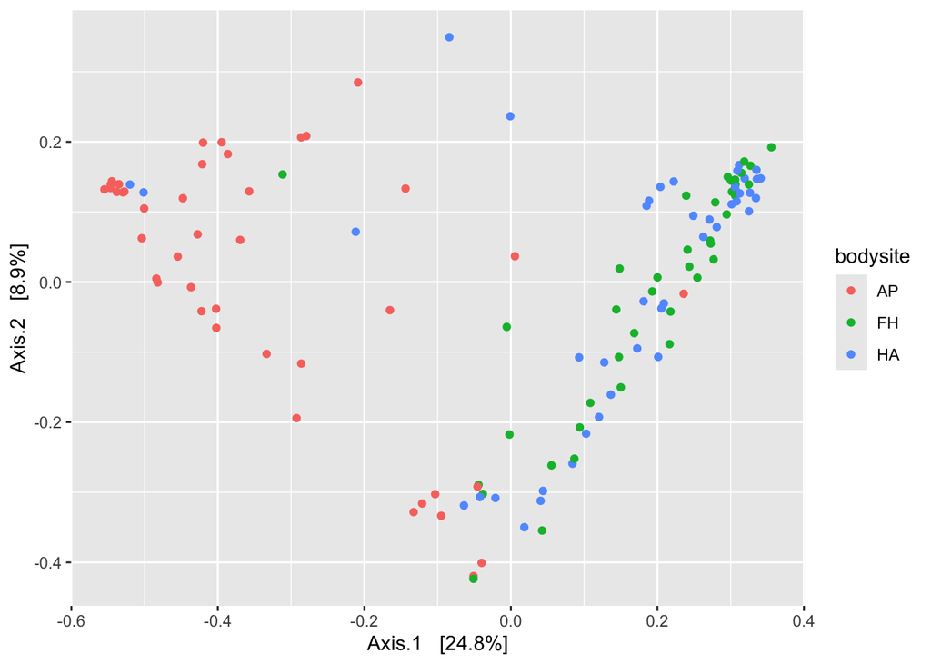

```r
plot_ordination(dada2_phyloseq_object, ord, color="bodysite")
```

The forehead and hands group together while the armpit is relatively distinct.

Other things we might find are:

- Potential outlier samples, so maybe a sample that got contaminated
- If we had negative controls, we would want to see them cluster away from our samples

We’ll use some of this information later, and dive deeper into everything I just did, but this is just one way that we can perform sanity checks super early on.

## 5.2 Negative Control Consideration

Unfortunately the publicly available data we have today doesn’t include the sequencing data from the extensive negative controls they used for quality control and mention in their paper. These can help us identify sequence reads that are likely arose from reagents or cross-sample contamination. For now, I will point to tools like DECONTAM[^3], which you can read about [here](https://microbiomejournal.biomedcentral.com/articles/10.1186/s40168-018-0605-2) and find the technical information [here](https://benjjneb.github.io/decontam/vignettes/decontam_intro.html). This package helps identify taxa that are likely to have arisen from negative controls and can remove them.

## 5.3 Removal of Lower-Abundance Taxa

This step is intended to remove very low abundance taxa from the dataset. These can arise through potential errors and ultimately increase the sparsity of the already-sparse data we analyze.

To determine how our taxa are distributed across our dataset, I like to plot a histogram of the log10 taxon counts within the dataset using a phyloseq function that can pull that information out (`taxa_sums`).

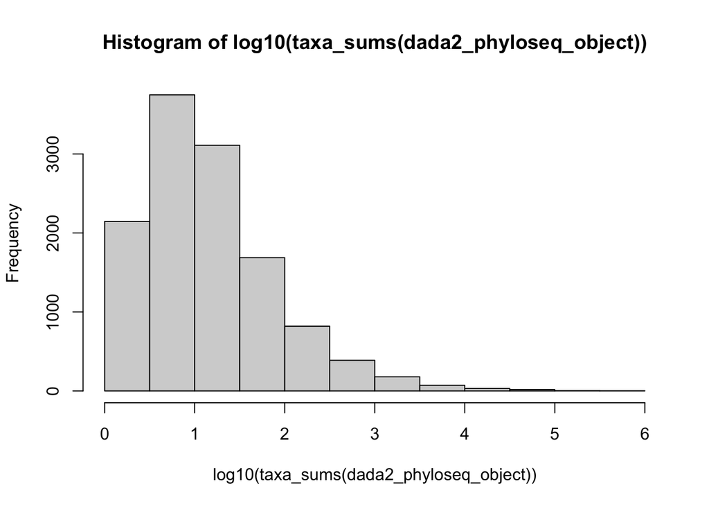

```r
hist(log10(taxa_sums(dada2_phyloseq_object)))
```

We can see from the plot that it is mostly comprised of low-abundance taxa. There are relatively few high-abundance taxa in the dataset.

For now, we’ll filter out just the ultra-low abundance taxa before proceeding. I typically do this by removing any taxon with less than 0.001% of the total reads, which I can calculate below.

```r
critical_value <- 0.00001*sum(taxa_sums(dada2_phyloseq_object))
dada2_phyloseq_filtered <- filter_taxa(dada2_phyloseq_object, function(x) sum(x) > critical_value, TRUE)
dada2_phyloseq_filtered
```

```
phyloseq-class experiment-level object
otu_table()   OTU Table:         [ 2498 taxa and 126 samples ]
sample_data() Sample Data:       [ 126 samples by 17 sample variables ]
tax_table()   Taxonomy Table:    [ 2498 taxa by 7 taxonomic ranks ]
phy_tree()    Phylogenetic Tree: [ 2498 tips and 2497 internal nodes ]
```

Our filtered dataset, especially in this instance, has many-fewer taxa but the actual overall number of reads in the table hasn’t changed that much.

```r
sum(taxa_sums(dada2_phyloseq_filtered))/sum(taxa_sums(dada2_phyloseq_object))
```

```
[1] 0.9752145
```

## 5.4 Normalization/Standardization

One last thing we need to do before starting the core of our analysis is standardize the counts between samples. We’ll start to do this by looking at the sequencing depth of our samples. Note that in the previous step we were looking at taxa sums and now we are looking at sample sums.

```r
summary(sample_sums(dada2_phyloseq_filtered))
```

```
   Min. 1st Qu.  Median    Mean 3rd Qu.    Max.
      5   30140   36326   35268   42014   75911
```

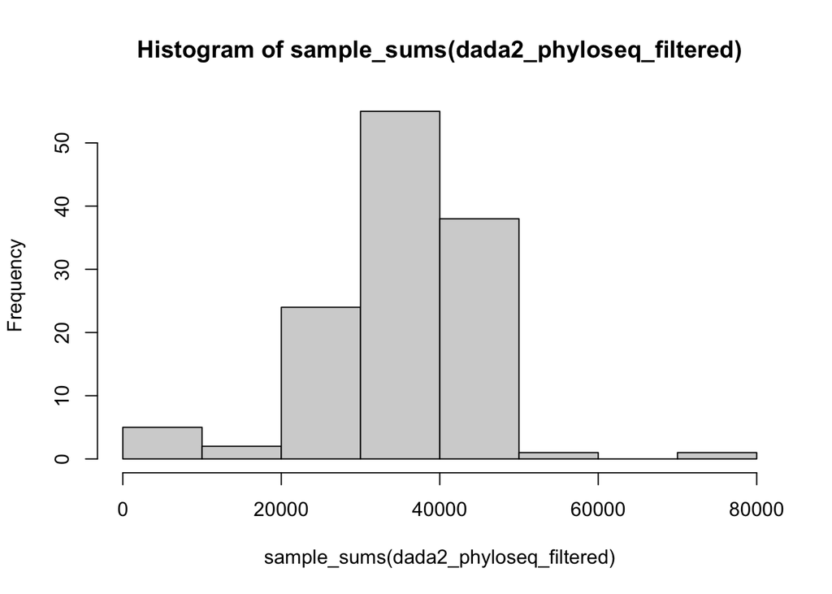

```r
hist(sample_sums(dada2_phyloseq_filtered))
```

Here we can see a wide variety of sequencing depth across samples. Some samples have very few reads, while others have several thousand. We typically want to “standardize” this in some way because differences in sequencing effort can contribute to potential bias. How this happens, though, is an area of active, lively debate that continues to this day. And new methods are being developed, though I haven’t seen uptake of the new methods changing very much.

A few papers on the topic are listed below if you want to read more.

> McMurdie PJ, Holmes S. Waste not, want not: why rarefying microbiome data is inadmissible. PLoS Comput Biol. 2014 Apr 3;10(4):e1003531. doi: 10.1371/journal.pcbi.1003531. PMID: 24699258; PMCID: PMC3974642.

> Weiss S, Xu ZZ, Peddada S, Amir A, Bittinger K, Gonzalez A, Lozupone C, Zaneveld JR, Vázquez-Baeza Y, Birmingham A, Hyde ER, Knight R. Normalization and microbial differential abundance strategies depend upon data characteristics. Microbiome. 2017 Mar 3;5(1):27. doi: 10.1186/s40168-017-0237-y. PMID: 28253908; PMCID: PMC5335496.

> McKnight, DT, Huerlimann, R, Bower, DS, Schwarzkopf, L, Alford, RA, Zenger, KR. Methods for normalizing microbiome data: An ecological perspective. Methods Ecol Evol. 2019; 10: 389–400. https://doi.org/10.1111/2041-210X.13115

> Lin H, Peddada SD. Analysis of microbial compositions: a review of normalization and differential abundance analysis. NPJ Biofilms Microbiomes. 2020 Dec 2;6(1):60. doi: 10.1038/s41522-020-00160-w. PMID: 33268781; PMCID: PMC7710733.

At any rate, the two main options are:

- Rarefaction: subsample all samples to an even read depth, typically one that captures the greatest amount of diversity for a majority of the samples and allows a majority of the samples to be retained. Alpha rarefaction curves, which are provided with the Nephele output, can help in determining a rarefaction depth.
- Normalization: fit the distribution of read counts to an expected distribution, typically Negative Binomial. There are many methods from several packages you can use to perform normalization. For instance, a popular transformation is the Variance Stabilized Transformation from the DESeq2 package. There’s also the Trimmed Mean of M-component (TMM) normalization available through the edgeR package, and the limma package has normalizations as well. Note that all of the methods I’ve listed got their start in RNAseq data; however, the key difference between microbiome data and RNAseq data is that RNAseq data is relatively dense (few zeros) and microbiome data ends up exceedingly sparse (many zeros), changing how these tools perform on microbiome data.

My personal preference is rarefaction, which has worked well for me over several datasets, and I’ll use that method today. I also prefer it because I can use the same “standardized” dataset across all of my analyses (alpha diversity, beta diversity, and significant taxa) without needing to re-normalize or change the relationships between my samples and taxa. However, you may want to consider normalization methods if you have too many lower-abundance samples that are needed for your analysis and cannot be otherwise removed.

To perform rarefaction, we’ll first review the alpha rarefaction curves found under `data/data2_outputs/graphs/rarecurve.html`. Given the plot, we will rarefy to 10,000 reads per sample, which is the depth that was chosen by the authors of the paper as well. At that depth, we retain a majority of the samples and have reached the asymptote of the curve for a majority of samples as well.

```r
dada2_rare <- rarefy_even_depth(dada2_phyloseq_filtered, sample.size = 10000, replace=F, rngseed=123)
```

```
`set.seed(123)` was used to initialize repeatable random subsampling.
```

```
Please record this for your records so others can reproduce.
```

```
Try `set.seed(123); .Random.seed` for the full vector
```

```
...
```

```
5 samples removedbecause they contained fewer reads than `sample.size`.
```

```
Up to first five removed samples are:
```

```
SRR12823339SRR12823384SRR12823406SRR12823421SRR12823432
```

```
...
```

```r
dada2_rare
```

```
phyloseq-class experiment-level object
otu_table()   OTU Table:         [ 2498 taxa and 121 samples ]
sample_data() Sample Data:       [ 121 samples by 17 sample variables ]
tax_table()   Taxonomy Table:    [ 2498 taxa by 7 taxonomic ranks ]
phy_tree()    Phylogenetic Tree: [ 2498 tips and 2497 internal nodes ]
```

# 6 Quick Stats Refresher

## 6.1 Types of Variables

There are also a few core types of variables that we’ll encounter today:

- *Continuous/Numeric/Integer*: These variables tend to be any set of numbers (examples include: systolic blood pressure)
- *Categorical/Factor/Character*: Characterized by having two or more values or categories (examples include: “floor type” in which the potential responses could be “hardwood”,“carpet”, or “tile”; “favorite fruit” with “apples”,“bananas”, “cherries”, or “dates” as potential responses). Also, sometimes continuous variables can be turned into categorical variables (ie, numeric cups of coffee can be grouped into categories of 1-2, 3-4, 5+)
- *Binary*: A special type of categorical variable that is typically coded as “Yes/No” or “0/1” (examples include: whether participants have the condition of interest or not, whether participants have siblings)

The type of variable you are analyzing has impacts for how the variable can be analyzed as well as how it is interpreted, so being aware of this throughout your analysis is vital.

**Activity**

Review the metadata we printed above and link a variable type to each variable.

## 6.2 Common Statistical Tests and When to Use Them

Using the information above, we can start now to talk about different statistical tests we can use for each type of data and for different types of distributions. I have made an attempt to describe when and where you might use different types of statistical tests in this “cheat sheet”. Note that this only covers relationships between one independent/outcome variable and one or more dependent/response variable(s).

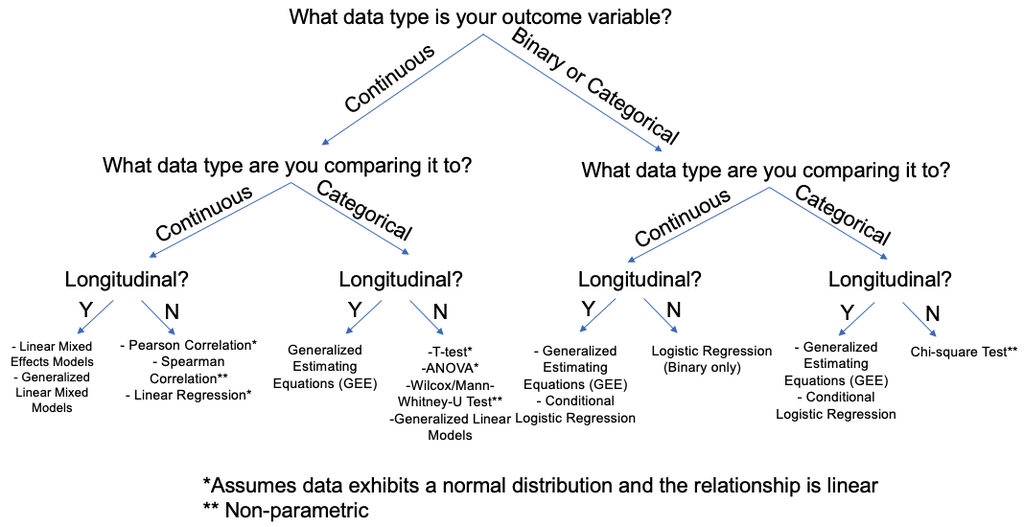

Statistical Test “Cheat Sheet”

Hopefully the workflow can serve as a general guide for which tests you might want to use. We are unable to cover everything today, but perhaps some of the other test types can serve as bread crumbs for future exploration. We will also cover a few tests beyond those covered in the above figure for some of the multi-dimensional statistics we use in microbiome data.

…Alright, let’s jump into some data!

# 7 Alpha Diversity

Allows us to ask: How many different types of sequences are in an environment (sample)?

There are several commonly used metrics, which act as a summary statistic for a single sample.

- Shannon’s Index: Takes into account both species richness and evenness - typically the backbone of other diversity metrics; higher values indicate more diverse and equally distributed communities, but it won’t be a direct count of the number of taxa present in a sample
- Pielou’s Evenness: Summarizes the distribution of taxa within a sample. “Uneven” communities are highly dominated by relatively few taxa.
- Chao1 Richness: Assumes that the counts of taxa within a sample estimates a Poisson distribution (a “normal” distribution for count data); takes the counts within a sample and corrects for deviations from the Poisson distribution
- Faith’s Phylogenetic Diversity: This metric includes additional phylogeny information in the calculation. Are there lots of taxa within one clade or do you get taxa from a variety of locations on the phylogenetic tree? This is calculated by taking the sum of the branches among taxa that occur within a sample.

**Activity**

If the two large circles below indicate two samples, which sample has higher Evenness? Which sample has higher richness?

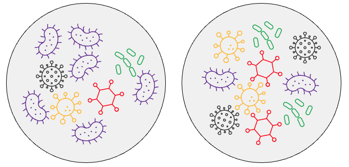

## 7.1 Calculating Alpha Diversity

Phyloseq includes a function that calculates some of the common diversity indices automatically. All calculations of alpha diversity must be done on rarefied data because otherwise the values for each sample end up highly driven by the sequencing depth for each sample.

```r
phy_alphadiv <- estimate_richness(dada2_rare)
head(phy_alphadiv)
```

```
            Observed     Chao1 se.chao1      ACE   se.ACE  Shannon   Simpson
SRR12823315      141 157.25000 8.428856 160.6757 6.259128 3.017935 0.8682614
SRR12823316      130 134.33333 3.403701 135.2580 5.496756 2.695784 0.8632047
SRR12823317       65  70.07692 4.035751  75.3443 4.298535 2.083353 0.7768187
SRR12823318      144 153.16667 7.381442 147.9173 5.941857 2.537172 0.6947330
SRR12823319      151 158.60000 4.688588 163.9563 6.298711 2.995361 0.8788274
SRR12823320      126 139.00000 9.257785 131.7386 5.537074 1.657887 0.4987869
            InvSimpson   Fisher
SRR12823315   7.590787 23.24155
SRR12823316   7.310193 21.09168
SRR12823317   4.480663  9.31243
SRR12823318   3.275821 23.83486
SRR12823319   8.252691 25.23057
SRR12823320   1.995159 20.32009
```

This gets us pretty far, but I also want to go over how you can calculate some of the common metrics “manually” and get others that aren’t in the default set for phyloseq. For this, we’ll use some components of the `vegan` package. This is a useful package that I think you should take the time to get to know. I would start [here](https://cran.r-project.org/web/packages/vegan/index.html), on the CRAN website, which includes several links to tutorials and FAQs developed by the package authors. The resources available across the internet about the `vegan` package have also bloomed in the past several years.

Below, I calculate evenness, Chao1 richness and phylogenetic diversity:

```r
library(vegan)
otu_table <- t(otu_table(dada2_rare))

evenness <- diversity(otu_table)/log(specnumber(otu_table)) #note that rowSums(otu_table > 0) == specnumber(otu_table)
chao1 <- t(estimateR(otu_table))[,2]
phy_div <- picante::pd(otu_table, phy_tree(dada2_rare), include.root = TRUE)[,1]
```

And we combine them all together here:

```r
all_alphadivs <- data.frame(phy_alphadiv, evenness, chao1, phy_div)
```

And then add them to our phyloseq object:

```r
update_sample_data <- merge(sample_data(dada2_rare), all_alphadivs, by=0)
rownames(update_sample_data) <- update_sample_data$Row.names
update_sample_data$Row.names <- NULL

sample_data(dada2_rare) <- update_sample_data
head(sample_data(dada2_rare))
```

```
                                        SampleID       ForwardFastqFile
SRR12823315  Amato.322.HSAP.USA.19.MM.4.HA.DRY.F SRR12823315_1.fastq.gz
SRR12823316  Amato.190.HSAP.MEX.19.MM.4.AP.DRY.F SRR12823316_1.fastq.gz
SRR12823317  Amato.180.HSAP.MEX.19.MM.1.AP.DRY.F SRR12823317_1.fastq.gz
SRR12823318  Amato.321.HSAP.USA.19.MM.4.AP.DRY.F SRR12823318_1.fastq.gz
SRR12823319  Amato.320.HSAP.USA.19.MM.4.FH.DRY.F SRR12823319_1.fastq.gz
SRR12823320 Amato.319.HSAP.USA.19.MM.24.AP.DRY.F SRR12823320_1.fastq.gz
                  ReverseFastqFile TreatmentGroup bodysite country population
SRR12823315 SRR12823315_2.fastq.gz             HA       HA     USA   Evanston
SRR12823316 SRR12823316_2.fastq.gz             AP       AP     MEX   Coatepec
SRR12823317 SRR12823317_2.fastq.gz             AP       AP     MEX   Ocotopec
SRR12823318 SRR12823318_2.fastq.gz             AP       AP     USA   Evanston
SRR12823319 SRR12823319_2.fastq.gz             FH       FH     USA   Evanston
SRR12823320 SRR12823320_2.fastq.gz             AP       AP     USA   Evanston
            age_months sex number_alloparents number_siblings C_section HH
SRR12823315         11   M                  1               1        No  3
SRR12823316          6   F                  2               1       Yes  6
SRR12823317          7   F                  4               3        No  6
SRR12823318         11   M                  1               1        No  3
SRR12823319         11   M                  1               1        No  3
SRR12823320         13   F                  3               1       Yes  3
            Mom_age_years  Mom_edu subject_id Description Observed     Chao1
SRR12823315           N/A Graduate   4-USA-HA SRR12823315      141 157.25000
SRR12823316            31      N/A   4-MEX-AP SRR12823316      130 134.33333
SRR12823317            34  Primary   1-MEX-AP SRR12823317       65  70.07692
SRR12823318           N/A Graduate   4-USA-AP SRR12823318      144 153.16667
SRR12823319           N/A Graduate   4-USA-FH SRR12823319      151 158.60000
SRR12823320           N/A Graduate  24-USA-AP SRR12823320      126 139.00000
            se.chao1      ACE   se.ACE  Shannon   Simpson InvSimpson   Fisher
SRR12823315 8.428856 160.6757 6.259128 3.017935 0.8682614   7.590787 23.24155
SRR12823316 3.403701 135.2580 5.496756 2.695784 0.8632047   7.310193 21.09168
SRR12823317 4.035751  75.3443 4.298535 2.083353 0.7768187   4.480663  9.31243
SRR12823318 7.381442 147.9173 5.941857 2.537172 0.6947330   3.275821 23.83486
SRR12823319 4.688588 163.9563 6.298711 2.995361 0.8788274   8.252691 25.23057
SRR12823320 9.257785 131.7386 5.537074 1.657887 0.4987869   1.995159 20.32009
             evenness     chao1  phy_div
SRR12823315 0.6098367 157.25000 17.41734
SRR12823316 0.5538295 134.33333 17.01519
SRR12823317 0.4990799  70.07692  6.78517
SRR12823318 0.5105166 153.16667 19.59490
SRR12823319 0.5970089 158.60000 17.48877
SRR12823320 0.3428020 139.00000 12.87072
```

## 7.2 Comparing Alpha Diversity

### 7.2.1 Running Linear Models

Our first question using this data is simple: is there a difference in phylogenetic diversity between countries at each body site? We already know that the composition between body sites is quite distinct, so this presents a nice place to start.

We can do this using linear models which allow us to perform this comparison. Note that I’m using the subset function to iteratively focus on each body site.

Also, when comparing categorical variables to a continuous variable, we typically need a reference group. In these examples, you see “countryUSA” to the right of all of the models, but no mention of Mexico. This is because Mexico is considered the reference group (because it is higher in alphabetical order). If you need to change this, you can use the `relevel(var, ref="MEX")` function, but we will keep the comparison we have here.

```r
# the update_sample_data object we created above actually is a nice format for our analysis here, so we will use that dataset.
summary(lm(phy_div ~ country, data=subset(update_sample_data, bodysite == "AP")))
```

```
Call:
lm(formula = phy_div ~ country, data = subset(update_sample_data,
    bodysite == "AP"))

Residuals:
    Min      1Q  Median      3Q     Max
-8.1533 -4.8732 -0.0582  3.4720 12.6684

Coefficients:
            Estimate Std. Error t value Pr(>|t|)
(Intercept)   13.409      1.235  10.858 2.37e-13 ***
countryUSA     0.422      1.768   0.239    0.813
---
Signif. codes:  0 '***' 0.001 '**' 0.01 '*' 0.05 '.' 0.1 ' ' 1

Residual standard error: 5.659 on 39 degrees of freedom
Multiple R-squared:  0.001458,  Adjusted R-squared:  -0.02415
F-statistic: 0.05695 on 1 and 39 DF,  p-value: 0.8126
```

```r
summary(lm(phy_div ~ country, data=subset(update_sample_data, bodysite == "HA")))
```

```
Call:
lm(formula = phy_div ~ country, data = subset(update_sample_data,
    bodysite == "HA"))

Residuals:
     Min       1Q   Median       3Q      Max
-15.5926  -4.6338   0.3832   4.0759  19.4384

Coefficients:
            Estimate Std. Error t value Pr(>|t|)
(Intercept)   22.446      1.682  13.347   <2e-16 ***
countryUSA    -5.935      2.351  -2.524   0.0156 *
---
Signif. codes:  0 '***' 0.001 '**' 0.01 '*' 0.05 '.' 0.1 ' ' 1

Residual standard error: 7.706 on 41 degrees of freedom
Multiple R-squared:  0.1345,    Adjusted R-squared:  0.1134
F-statistic: 6.372 on 1 and 41 DF,  p-value: 0.01556
```

```r
summary(lm(phy_div ~ country, data=subset(update_sample_data, bodysite == "FH")))
```

```
Call:
lm(formula = phy_div ~ country, data = subset(update_sample_data,
    bodysite == "FH"))

Residuals:
     Min       1Q   Median       3Q      Max
-13.5493  -5.5266  -0.3119   4.0670  15.1530

Coefficients:
            Estimate Std. Error t value Pr(>|t|)
(Intercept)   26.340      1.834  14.360 3.08e-16 ***
countryUSA    -7.543      2.379  -3.171  0.00316 **
---
Signif. codes:  0 '***' 0.001 '**' 0.01 '*' 0.05 '.' 0.1 ' ' 1

Residual standard error: 7.104 on 35 degrees of freedom
Multiple R-squared:  0.2232,    Adjusted R-squared:  0.201
F-statistic: 10.05 on 1 and 35 DF,  p-value: 0.003155
```

These results suggest that when comparing countries, only the phylogenetic diversity of the hand and forehead are significantly different, and both exhibit lower phylogenetic diversity in the USA compared to Mexico.

Let’s explore another interesting, *linear* variable: **age**. In these results, we no longer have a reference group, but calculate the coefficient as the unit change in phylogenetic diversity for every unit-increase in age. In other words, for the first statistical test we do below, there is a 0.2983-unit increase in phylogenetic diversity for every month of life increase, which is significant (P=0.00925).

```r
summary(lm(phy_div ~ age_months, data=subset(update_sample_data, bodysite == "AP")))
```

```
Call:
lm(formula = phy_div ~ age_months, data = subset(update_sample_data,
    bodysite == "AP"))

Residuals:
   Min     1Q Median     3Q    Max
-8.256 -3.964 -1.162  3.568 11.746

Coefficients:
            Estimate Std. Error t value Pr(>|t|)
(Intercept)  10.1555     1.5005   6.768 4.47e-08 ***
age_months    0.2983     0.1089   2.739  0.00925 **
---
Signif. codes:  0 '***' 0.001 '**' 0.01 '*' 0.05 '.' 0.1 ' ' 1

Residual standard error: 5.187 on 39 degrees of freedom
Multiple R-squared:  0.1613,    Adjusted R-squared:  0.1398
F-statistic:   7.5 on 1 and 39 DF,  p-value: 0.00925
```

```r
summary(lm(phy_div ~ age_months, data=subset(update_sample_data, bodysite == "HA")))
```

```
Call:
lm(formula = phy_div ~ age_months, data = subset(update_sample_data,
    bodysite == "HA"))

Residuals:
   Min     1Q Median     3Q    Max
-9.087 -4.384 -1.295  1.957 27.183

Coefficients:
            Estimate Std. Error t value Pr(>|t|)
(Intercept)  13.3971     2.0909   6.407 1.14e-07 ***
age_months    0.5217     0.1535   3.400  0.00151 **
---
Signif. codes:  0 '***' 0.001 '**' 0.01 '*' 0.05 '.' 0.1 ' ' 1

Residual standard error: 7.316 on 41 degrees of freedom
Multiple R-squared:  0.2199,    Adjusted R-squared:  0.2009
F-statistic: 11.56 on 1 and 41 DF,  p-value: 0.001513
```

```r
summary(lm(phy_div ~ age_months, data=subset(update_sample_data, bodysite == "FH")))
```

```
Call:
lm(formula = phy_div ~ age_months, data = subset(update_sample_data,
    bodysite == "FH"))

Residuals:
    Min      1Q  Median      3Q     Max
-16.273  -4.157  -1.909   1.962  19.279

Coefficients:
            Estimate Std. Error t value Pr(>|t|)
(Intercept)  18.9772     2.6332   7.207 2.07e-08 ***
age_months    0.2312     0.1842   1.256    0.218
---
Signif. codes:  0 '***' 0.001 '**' 0.01 '*' 0.05 '.' 0.1 ' ' 1

Residual standard error: 7.884 on 35 degrees of freedom
Multiple R-squared:  0.0431,    Adjusted R-squared:  0.01576
F-statistic: 1.577 on 1 and 35 DF,  p-value: 0.2176
```

## 7.3 Visualizing Alpha Diversity

Visualization of alpha diversity is relatively straight forward and is typically performed through box and whiskers plots, which are easy to create with ggplot2.

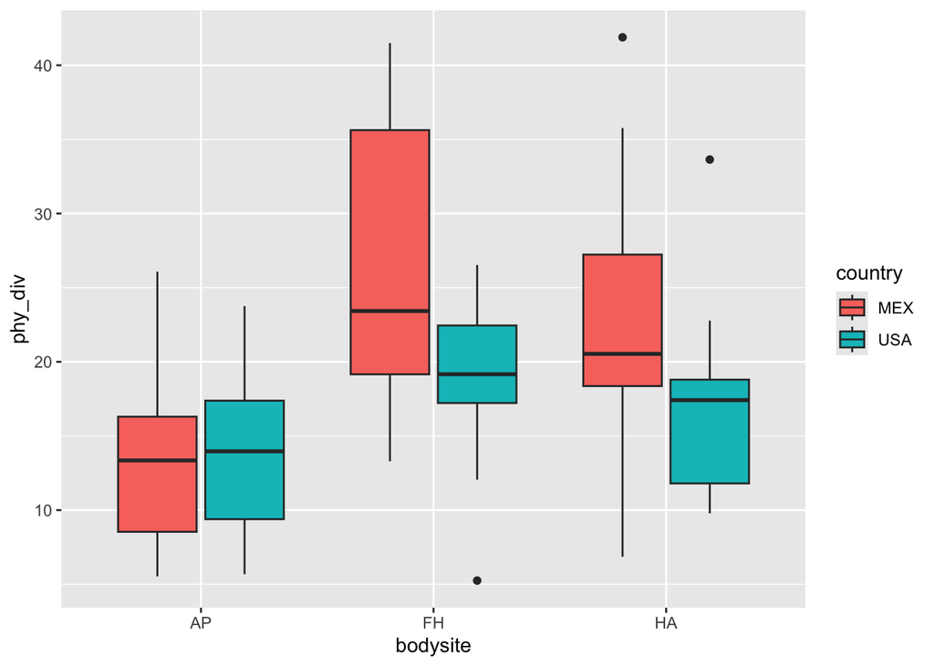

```r
library(ggplot2)
ggplot(update_sample_data, aes(x=bodysite, y=phy_div, fill=country)) +
  geom_boxplot()
```

We can see from this plot that forehead and hand samples differ in diversity between Mexico and USA, with Mexico typically having higher diversity.

**Activity**

Repeat the process for `age_months`.

# 8 Beta Diversity

Beta diversity allows us to understand effects observed across samples obtained from the population being studied, and allows us to analyze samples in the context of other samples.

Samples are compared to each other based on different calculations of distances. Each distance allows us to learn something new about our data:

- Bray Curtis: Weights the distances based on **higher** abundance taxa
- Canberra: Weights the distances based on **lower** abundance taxa
- UniFrac: uses the phylogenetic tree to help calculate the distances
  - Weighted UniFrac combines phylogeny with the abundances, focusing more on the higher abundance taxa (basically Bray Curtis + phylogeny)
  - Unweighted UniFrac: simply focuses on the phylogenetic information without regard to abundance

## 8.1 What is a distance matrix?

It is an “n x n” matrix (meaning that it has samples on the rows and the columns) that is based on a calculation of distances.

This is an example built from our practice data today. You can see that each of the rows and columns is a sample that gets compared to itself.

```r
## note the use of the explicit call to phyloseq for the distance function -- there are many different distance functions and sometimes they can get mixed up.
distance_matrix <- phyloseq::distance(dada2_rare, method="bray")
as.matrix(distance_matrix)[1:5,1:5]
```

```
            SRR12823315 SRR12823316 SRR12823317 SRR12823318 SRR12823319
SRR12823315      0.0000      0.9547      0.9802      0.7357      0.3247
SRR12823316      0.9547      0.0000      0.4274      0.6310      0.9390
SRR12823317      0.9802      0.4274      0.0000      0.5760      0.9735
SRR12823318      0.7357      0.6310      0.5760      0.0000      0.7198
SRR12823319      0.3247      0.9390      0.9735      0.7198      0.0000
```

**Activity**

Which sample pair is most similar? Most distinct?

## 8.2 Calculating Beta Diversity

We can calculate several types of distance matrices using phyloseq through the `distance` function. Generating this distance using phyloseq is exceptionally easy. UniFrac distances can be easily made because the tree is already contained within the phyloseq object.

A Bray Curtis distance matrix was created above, but we can also calculate a weighted UniFrac distance matrix (using the phylogenetic tree) very easily

```r
weighted_distance <- phyloseq::distance(dada2_rare, method="wunifrac")
as.matrix(weighted_distance)[1:5,1:5]
```

```
            SRR12823315 SRR12823316 SRR12823317 SRR12823318 SRR12823319
SRR12823315  0.00000000  0.18556907  0.17582194   0.1005602  0.06119036
SRR12823316  0.18556907  0.00000000  0.07834129   0.1331202  0.17921405
SRR12823317  0.17582194  0.07834129  0.00000000   0.1320220  0.17395040
SRR12823318  0.10056024  0.13312025  0.13202198   0.0000000  0.10875960
SRR12823319  0.06119036  0.17921405  0.17395040   0.1087596  0.00000000
```

## 8.3 Comparing Beta Diversity

Now we want to start relating this diversity to variables of interest. Our first question will be similar to the previous question we asked: are there compositional differences in the skin microbiome between USA and Mexico?

To answer this question, we’ll use a special statistical method called Permutational Analysis of Variance or PERMANOVA, developed by Marti J Anderson[^4], that specifically analyzes distance matrices.

It allows us to ask whether a specific variable “explains a significant proportion of variance” across microbial communities. This is done by calculating a baseline F statistic, which is a comparison of variance (total sum of squares) both within groups and between groups.

From this we can calculate a p-value by shuffling the distance matrix around many times (default = 999) and then re-calculate the F-statistic. The p-value then becomes the proportion of times that the permuted F-statistics are greater than the overall F-statistic (aka, the literal definition of a p-value).

To perform this comparison, we actually don’t need to do any of this manually. We place our calculated distance matrix into the “response” variable part of a model, which can be done using the `vegan` package’s `adonis2` function. I am also subsetting this data first to focus on the community composition differences at each body site.

```r
dada2_rare_ap <- subset_samples(dada2_rare, bodysite %in% "AP")
dada2_rare_ha <- subset_samples(dada2_rare, bodysite %in% "HA")
dada2_rare_fh <- subset_samples(dada2_rare, bodysite %in% "FH")
adonis2(phyloseq::distance(dada2_rare_ap, method="wunifrac") ~ sample_data(dada2_rare_ap)$country)
```

```
Permutation test for adonis under reduced model
Permutation: free
Number of permutations: 999

adonis2(formula = phyloseq::distance(dada2_rare_ap, method = "wunifrac") ~ sample_data(dada2_rare_ap)$country)
         Df SumOfSqs      R2      F Pr(>F)
Model     1  0.03198 0.07274 3.0595  0.028 *
Residual 39  0.40767 0.92726
Total    40  0.43965 1.00000
---
Signif. codes:  0 '***' 0.001 '**' 0.01 '*' 0.05 '.' 0.1 ' ' 1
```

```r
adonis2(phyloseq::distance(dada2_rare_ha, method="wunifrac") ~ sample_data(dada2_rare_ha)$country)
```

```
Permutation test for adonis under reduced model
Permutation: free
Number of permutations: 999

adonis2(formula = phyloseq::distance(dada2_rare_ha, method = "wunifrac") ~ sample_data(dada2_rare_ha)$country)
         Df SumOfSqs     R2      F Pr(>F)
Model     1  0.02123 0.0586 2.5519  0.021 *
Residual 41  0.34110 0.9414
Total    42  0.36233 1.0000
---
Signif. codes:  0 '***' 0.001 '**' 0.01 '*' 0.05 '.' 0.1 ' ' 1
```

```r
adonis2(phyloseq::distance(dada2_rare_fh, method="wunifrac") ~ sample_data(dada2_rare_fh)$country)
```

```
Permutation test for adonis under reduced model
Permutation: free
Number of permutations: 999

adonis2(formula = phyloseq::distance(dada2_rare_fh, method = "wunifrac") ~ sample_data(dada2_rare_fh)$country)
         Df SumOfSqs      R2      F Pr(>F)
Model     1 0.025847 0.09302 3.5896  0.001 ***
Residual 35 0.252022 0.90698
Total    36 0.277869 1.00000
---
Signif. codes:  0 '***' 0.001 '**' 0.01 '*' 0.05 '.' 0.1 ' ' 1
```

The results we got above suggest that the USA and Mexico have a significantly different microbiome composition at each body site. There are a few key points of interest in this result that I also want to point out. The columns, in order, indicate: degrees of freedom, Sum of Squares (see variance calculation above), the R-squared value (or the proportion of variance explained by the variable), the critical F-statistic, and the P-value.

**Question**

Run an `adonis2` function a second time. What happened? Why?

**Question**

Keeping in mind the results from above, try comparing composition using a different distance matrix. Can we learn anything new? What about another variable?

**Caution**

I should say one word of warning – I’m able to do this in a more “simple” way because I know that the order of samples in the OTU/ASV table from the phyloseq object is in the same order as it will be in the distance matrix, which is in the same order as the sample data. If the distance matrix comes from some other data-generating process and there is *any* chance that the samples are in a different order, you will still get an R2 and P-value and no warning will be produced, but the results are unlikely to be accurate.

If you want to double check, you can try something like this:

```r
identical(labels(weighted_distance), rownames(sample_data(dada2_rare)))
```

```
[1] TRUE
```

## 8.4 Visualizing Beta Diversity

To visualize these findings, we typically use ordination, which is what I hinted at while discussing the initial steps I take when I look at new data. This process takes the pairwise distances that were calculated above and used in the `adonis2` function and places them into “coordinate” space so that we can view them. The two main methods of ordination are:

- **Principal Coordinates Analysis (PCoA)**: This method is also known as “Metric Multi-Dimensional Scaling (MDS)” and arranges the points similarly to how they are arranged in the distance matrix. Using this method results in a number of *eigenvalues* that can be used as axes to represent the approximate distances.
- **Non-metric Multi-Dimensional Scaling (NMDS)**: Instead of focusing on the actual distances themselves, NMDS takes a more non-parametric approach, focusing on ensuring that the ranks of the distances are correctly spaced.

Both methods try to optimize the distances so that the majority of the variance is explained in as few axes as possible. PCoA does the best that it can, and NMDS forces the distances into a pre-defined number of axes.

In phyloseq, both are again straight-forward if we use the `ordinate` function. We can also see some of the standard output of the NMDS method, showing some of the iterations it takes.

```r
pcoa_ord <- ordinate(dada2_rare_ha, method="PCoA", distance="wunifrac")
nmds_ord <- ordinate(dada2_rare_ha, method="NMDS", distance="wunifrac")
```

```
*** Best solution was not repeated -- monoMDS stopping criteria:
    20: stress ratio > sratmax
```

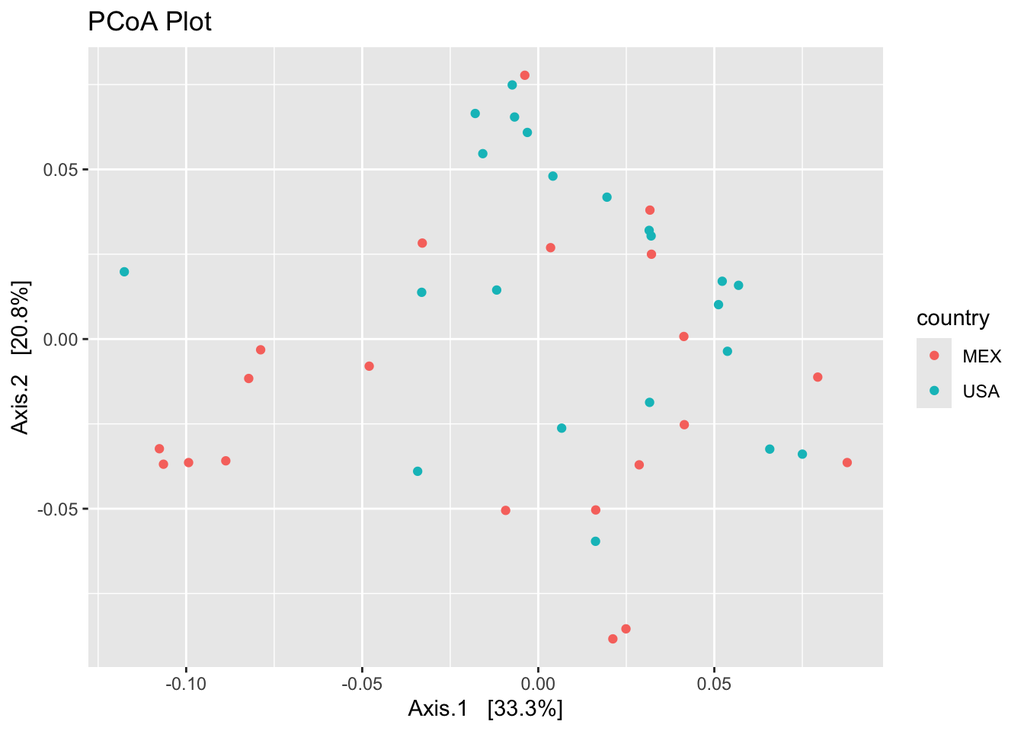

```r
plot_ordination(dada2_rare_ha, pcoa_ord, color="country") + ggtitle("PCoA Plot")
```

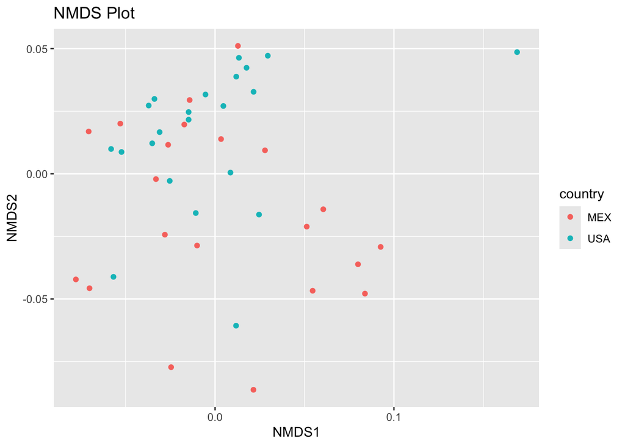

```r
plot_ordination(dada2_rare_ha, nmds_ord, color="country") + ggtitle("NMDS Plot")
```

One thing I like to do is use elipses from ggplot to help understand the characteristics of the differences between groups, and can be added easily:

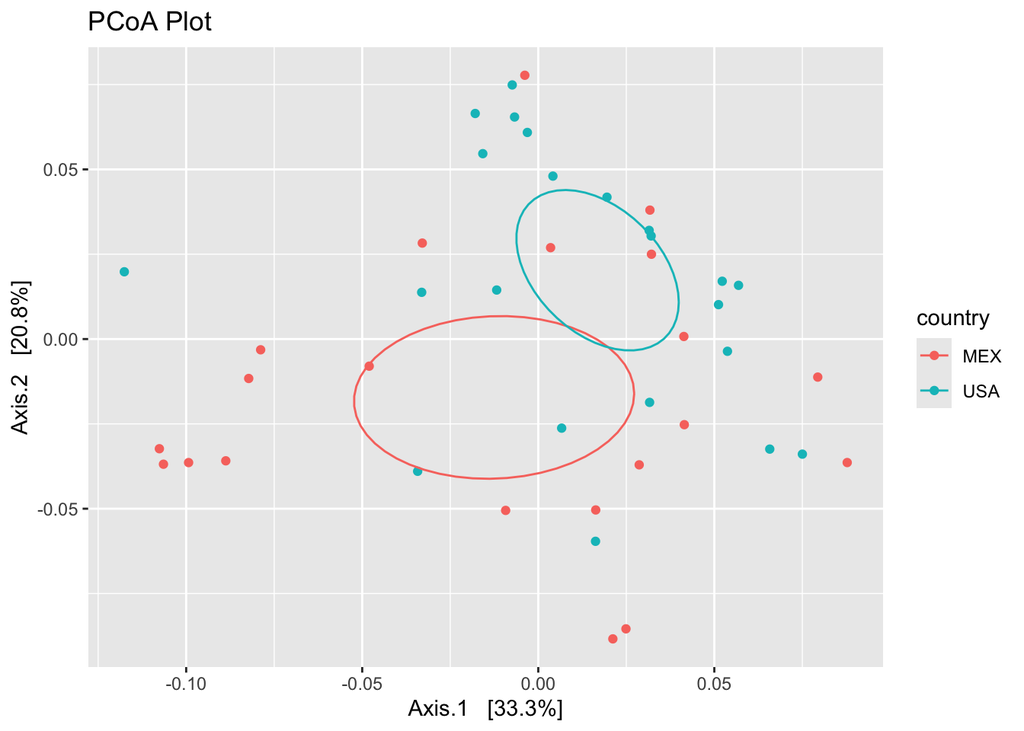

```r
plot_ordination(dada2_rare_ha, pcoa_ord, color="country") + ggtitle("PCoA Plot") + stat_ellipse(level=0.2)
```

Here, I’m using a 20% “confidence level” for the ellipses, and it’s typically the level I always use. It tends to reflect the significance of a PERMANOVA and the placement of the points pretty well. If you want, you can experiment with other “levels” and find the one that you prefer.

# 9 Significant Taxa

Another very standard analysis that we’ll focus on today is comparing the abundance of taxa. It’s all fine and good that we see large compositional differences between the USA and Mexico, but until we know specifically what taxa appear to be differentially abundant, it’s hard to speculate about the biological importance of that difference.

## 9.1 Comparing Taxa

Again, there are several different approaches for analyzing differential abundance, and the debate is very active and very passionate. As I did before, below are some papers that give you a taste for not only this debate but the diversity of options and approaches:

> Nearing JT, Douglas GM, Hayes MG, MacDonald J, Desai DK, Allward N, Jones CMA, Wright RJ, Dhanani AS, Comeau AM, Langille MGI. Microbiome differential abundance methods produce different results across 38 datasets. Nat Commun. 2022 Jan 17;13(1):342. doi: 10.1038/s41467-022-28034-z. Erratum in: Nat Commun. 2022 Feb 3;13(1):777. PMID: 35039521; PMCID: PMC8763921.

> Yang L, Chen J. Benchmarking differential abundance analysis methods for correlated microbiome sequencing data. Brief Bioinform. 2023 Jan 19;24(1):bbac607. doi: 10.1093/bib/bbac607. PMID: 36617187; PMCID: PMC9851339.

I want to specifically highlight the database established by the paper below, [BugSigDB](https://bugsigdb.org/Main_Page). The database uses *manual curation* of 831 studies (as of October 26, 2023) to identify the methods used and taxa most frequently observed as differential.

> Geistlinger L, Mirzayi C, Zohra F, Azhar R, Elsafoury S, Grieve C, Wokaty J, Gamboa-Tuz SD, Sengupta P, Hecht I, Ravikrishnan A, Gonçalves RS, Franzosa E, Raman K, Carey V, Dowd JB, Jones HE, Davis S, Segata N, Huttenhower C, Waldron L. BugSigDB captures patterns of differential abundance across a broad range of host-associated microbial signatures. Nat Biotechnol. 2023 Sep 11. doi: 10.1038/s41587-023-01872-y. Epub ahead of print. PMID: 37697152.

For now, I will show you how I use one particularly flexible tool called **Maaslin2**. I’m still interested in the comparison of countries, and want to know what specific taxa are enriched among the forehead samples in the USA vs Mexico.

Maaslin2 was developed to be used directly in R or on the command line, but the “in-R” documentation (that you get if you run `?Maaslin`) could be better. For now, I’ll point you to [the website for Maaslin](https://huttenhower.sph.harvard.edu/maaslin/) so that we can learn about which options are available.

### 9.1.1 Filtering for Differential Abundance

Sometimes, datasets can have immense diversity, and it is important to focus on features that are likely to be the most relevant. In addition, when we perform so many statistical tests, we run the risk of “Type I error”, or having a significant finding that is in fact only significant by chance (because so many tests were performed).

We can use **prevalence** to filter down to taxa that could be most informative. Prevalence is the proportion of samples with any counts for a taxon. Therefore, an ASV present in 4 of 10 samples is 40% prevalent.

Maaslin2 has a few other parameters that you can use to filter down to taxa that are likely to be more important before a single p-value is generated, but we won’t cover them today.

When we’re reviewing our results, we use a False Discovery Rate (FDR)-corrected p-value, sometimes called a q-value, to rank our findings. There are a handful of different methods for calculating q-values, but I won’t go into them here. Their primary goal is to help us avoid the “Type I error” of performing a large number of statistical tests and comparing them.

## 9.2 Running Maaslin2

In example I’m working with today, I’m:

- using the forehead dataset to compare taxa between our two countries of interest
- considering a q-value of 0.25 to be considered “significant” by the software (though we’ll set our own limits later)
- using no normalization of my rarefied data, but log-transforming it and analyzing with a linear model [^5]
- enforcing a minimum prevalence of 40%, which means a taxon must be present in ~15 samples for it to be analyze.

```r
library(Maaslin2)
capture.output(
  run_maaslin <- Maaslin2(input_data= data.frame(otu_table(dada2_rare_fh)),
           input_metadata = data.frame(sample_data(dada2_rare_fh)),
           output="maaslin2_results",
           fixed_effects = c("country"),
           max_significance = 0.25,
           normalization = "NONE",
           transform="LOG",
           analysis_method="LM",
           min_prevalence = 0.4,
           ), file="maaslin2_stdout.txt"
)
```

Running Maaslin2 creates the following table:

```r
all_res <- run_maaslin$results
head(all_res)
```

```
  feature metadata value      coef    stderr         pval       name
1   seq73  country   USA -3.208546 0.5672518 2.191961e-06 countryUSA
2   seq92  country   USA -4.281596 0.7708351 2.986552e-06 countryUSA
3  seq112  country   USA -2.858284 0.5977630 3.097365e-05 countryUSA
4   seq35  country   USA -4.085656 0.8742495 4.286064e-05 countryUSA
5  seq114  country   USA -3.121635 0.6975973 7.748068e-05 countryUSA
6  seq122  country   USA -2.650248 0.6760418 3.929732e-04 countryUSA
          qval  N N.not.zero
1 0.0001956192 37         29
2 0.0001956192 37         21
3 0.0013525160 37         17
4 0.0014036860 37         25
5 0.0020299937 37         21
6 0.0085799153 37         16
```

Here, we can see:

- “feature”: the feature of interest
- “metadata”:
- “value”: the comparator category (since it’s a categorical variable) - the reference would be the category not mentioned
- “coef”: the coefficient indicating the effect size of the relationship
- “stderr”: standard error/variation around the mean for that taxon/feature
- “pval: the raw, unadjusted p-value
- “name”: combination of metadata and value
- “qval”: a p-value adjusted for the multiple comparisons performed
- “N”: number of samples that contributed to the analysis
- “N.not.zero”: number of non-zero values for that taxon; it can help identify “zero-inflated” taxa

**Maaslin2** went through each taxon individually and related it to whether it was higher or lower in the USA vs Mexico. Positive `coef` values indicate the taxon was higher in the USA compared to Mexico, while negative values indicate the taxon was higher in Mexico compared to USA.

## 9.3 Visualizing Taxa

Maaslin kindly produces some boxplots of significant taxa that are accessible within the output directory. I tend to use them for quick review when I need them (ie, if I need to see how stable my results appear to be), and we can make a few boxplots ourselves here:

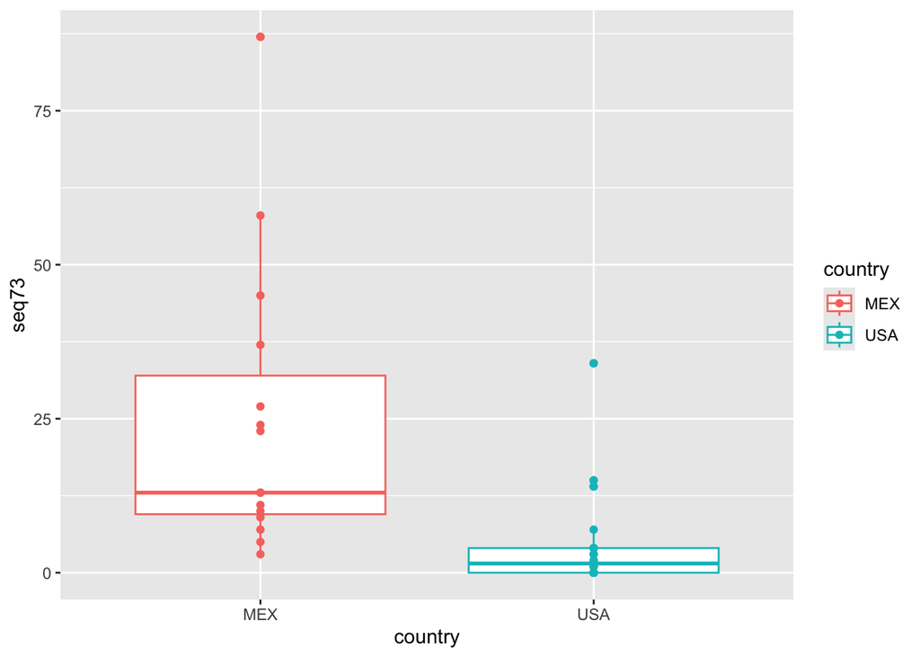

```r
combined_counts <- merge(t(otu_table(dada2_rare_fh)), sample_data(dada2_rare_fh), by=0)

ggplot(combined_counts, aes(x=country, y=seq73, color=country)) + geom_boxplot() + geom_point()
```

Another plot I generate after running any differential abundance analysis is a volcano plot. You’ve seen these for other types of data before and they are helpful because they can be quickly interpretable – the most significant ASVs rise to the top.

In its most basic form, a volcano plot can still be interesting.

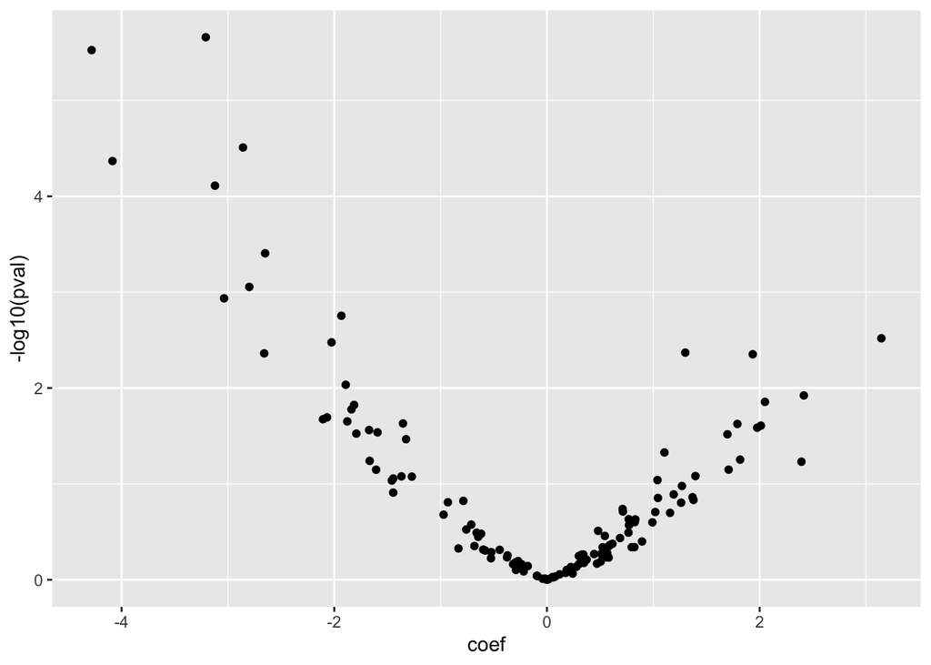

```r
ggplot(all_res, aes(x=coef, y=-log10(pval))) + geom_point()
```

However, its power lies in the ability to add different layers of information. Below, I add color and Genus-level labels to the significant taxa (separating them from the non-significant taxa which remain grey). You can get as pretty and technical as your heart desires with this plot.

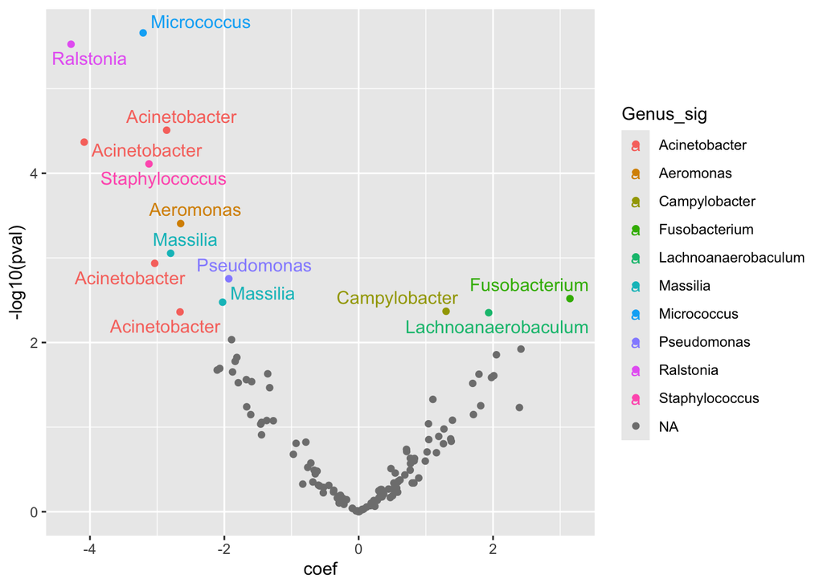

```r
all_res_tax <- merge(all_res, tax_table(dada2_rare), by.x="feature", by.y=0) #merge my differential taxa with the taxonomy information
all_res_tax$Genus_sig <- ifelse(all_res_tax$qval < 0.05, all_res_tax$Genus, NA) # create a new variable that only focuses on the significant Genera (missing otherwise)

## Plot
ggplot(all_res_tax, aes(x=coef, y=-log10(pval), color=Genus_sig)) +
  geom_point() +
  ggrepel::geom_text_repel(data=subset(all_res_tax, qval < 0.05), aes(label=Genus))
```

**Tip**

Using what we’ve learned, perform differential abundance analysis:

- using a different body site
- comparing forehead vs hand among participants from Mexico
- devise your own question based on what we’ve explored today

## 9.4 Wrap-up

Thank you for joining today! If you have feedback, ideas for additional sessions, questions about your own project, etc, feel free to reach out to me (kathryn.mccauley@nih.gov) or make a ticket to work with the Bioinformatics team (https://niaid-amp.powerappsportals.us/) and we would be happy to assist.

## Footnotes

[^1]: McMurdie PJ, Holmes S. Phyloseq: a bioconductor package for handling and analysis of high-throughput phylogenetic sequence data. Pac Symp Biocomput. 2012:235-46. PMID: 22174279; PMCID: PMC3357092.
[^2]: https://pubmed.ncbi.nlm.nih.gov/33144313/
[^3]: Davis, N.M., Proctor, D.M., Holmes, S.P. et al. Simple statistical identification and removal of contaminant sequences in marker-gene and metagenomics data. Microbiome 6, 226 (2018). https://doi.org/10.1186/s40168-018-0605-2
[^4]: Anderson, M.J. (2017). Permutational Multivariate Analysis of Variance (PERMANOVA). In Wiley StatsRef: Statistics Reference Online (eds N. Balakrishnan, T. Colton, B. Everitt, W. Piegorsch, F. Ruggeri and J.L. Teugels). https://doi.org/10.1002/9781118445112.stat07841
[^5]: For my “model-fit tests”, I took the sum of the residuals (which is the difference between the model’s prediction and the actual value) using `rowSums(run_maaslin$residuals)` for each taxon and saw that the linear model with a log transformation provided the lowest values (ie, the lowest difference between prediction and actual values)